# Case example 2: Integrating biological replicates

### Background:

In this case example we’ll see how to integrate several samples into one dataset. Integrating samples will allow us to minimize technical differences and biases in order to compare cells and cell clusters across different samples and conditions.

For this experiment we will use four samples of epididymal white adipose tissue, two from obese mice and two from lean mice, from [Sárvári et al. (Cell Metabolism, 2021)](https://www.ncbi.nlm.nih.gov/geo/query/acc.cgi?acc=GSE160729). Since a large number of cells were sequenced for this study, for practical purposes in this tutorial we will use a random sample of 3000 cells per experiment.

The study follows this design:

| Sample | Replica | Condition |
| --- | --- | --- |
| GSE160729_HDF_1 | 1 | High.Fat.Diet |
| GSE160729_HDF_2 | 2 | High.Fat.Diet |
| GSE160729_LDF_1 | 1 | Low.Fat.Diet |
| GSE160729_LDF_2 | 2 | Low.Fat.Diet |

Our final aim with this integration process will be to compare cell type diversity and gene expression dependent on the diet of each mice.

### Loading data

In the **Sample Integration** tab, let’s start by choosing a project name and selecting the four files corresponding with our samples. The “dataset list” table below will display the files we’ve got selected as we go. After selecting the four RDS files, in the next section select the sample metadata file “sampleData.tsv”, which will add data on which replica and condition correspond to each sample.

Since these are independent biological replicas with different conditions, we’ll need to correct for technical biases across samples, so in “Type of merge” select “Sample integration”. As for the normalization step, both can be used, but SCT-normalization will ussually produce better results, and since the datasets in this example are on the smaller side, computational resources shoudn’t be an issue.

If we’re working with a larger study or very limited resources, some other options would be:

- Reducing the number of integration features.
- Loading each sample individually and filtering out low quality cells before integration. It is also a good approach to regress cell cycle effects or mt-RNA percentage before integration.

### Quality control

Even if we have filter out low quality cells individually, checking quality measurements again after integration is a good idea, just in case we find any imbalace across samples -for instance, in ribosomal RNA or chromosome Y expression-.

In this case, no filtering has been done yet, so we should expect a significan number of low read counts and gene counts. To be able to distinguich each sample, select “orig.ident” (*original identity*) as grouping variable. Let’s take a look at the QC results:

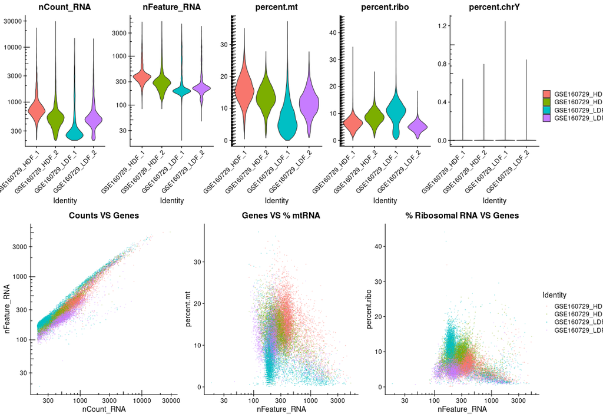

As we can see, there’s quite the variation. Sample LFD_1 has lower quality cell as a general rule, with both lower read counts and fewer genes detected. A minimum limit of 500 detected genes seems a good place to start, even though, since we’re using subsets of the original data, we’ll end up with only ~2500 cells. Will use this minimum value in the filter tab and regress the efect of ribosomal RNA percentage.

Sometimes during quality assesment steps we’ll filter our most of the cells in our samples. In cases like this is important to have in mind that different cell types can be more or less sensitive to the treatments in single cell protocols. We will just proceed with the resulting small “clean” dataset in this tutorial, but as a general rule, down the line is convenient to check if we’re keeping the cell diversity of our tissue as desired, or if our sample could have an important protocol-dependent bias.

Now, let’s see the QC results after filtering the cells:

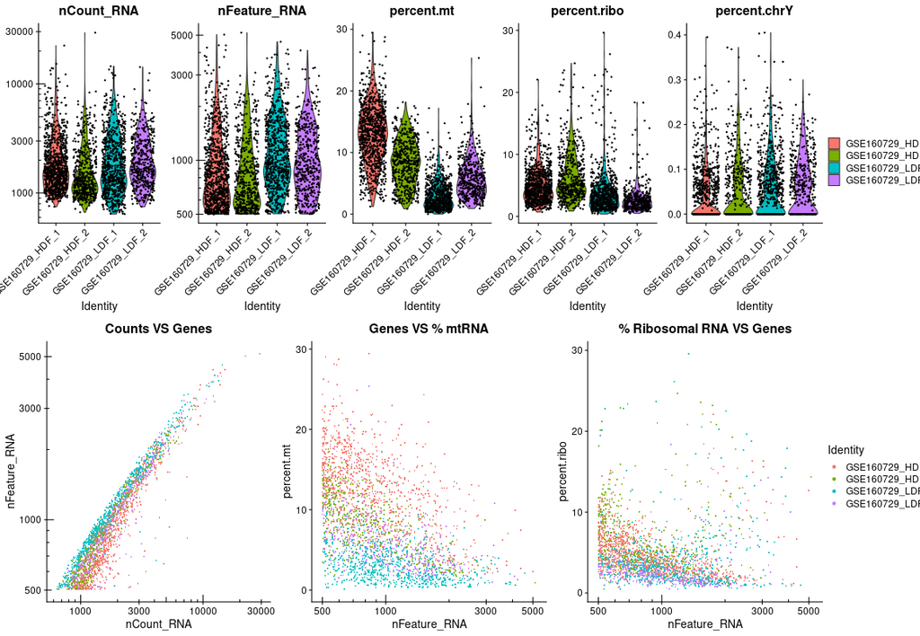

QC measurements seem more balanced now with regards to read and gene counts. At this stage we can also observe that there is a larger gap in mitocondrial RNA % between samples. To correct this we would return to the individual samples and perform variable regression before integration.

Next we’ll follow the same steps as in Case Example 1 to cluster the cells in our sample and generate a 2D visualization. In this case as parameters for the clustering algorithm we have used 15 principal components and a clustering resolution of 0.3. For the UMAP reduction, we have set the number of neighbours on 35 and minimum distante at 0.45.

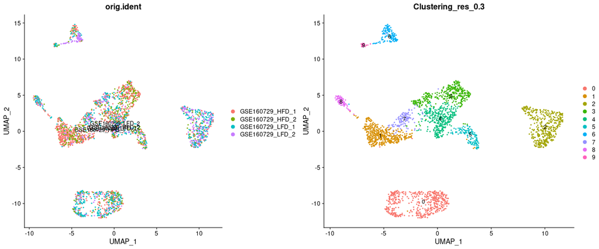

Notice how, for the most part, cells from the different samples are distributed across the plot. Variation in treatments or experimental conditions in most cases will have some influence over the cell types in a sample, but rarely this difference will be so deep as to separate the cells from each sample.

When sample integration fails, or technical and biological replicates are simply joined together without correction, technical biases will cause most of the difference between cells, taking a large influence on clustering results and 2D reductions. Below this paragraph there are the resulst of following the same process, but with these four samples merge together without any correction:

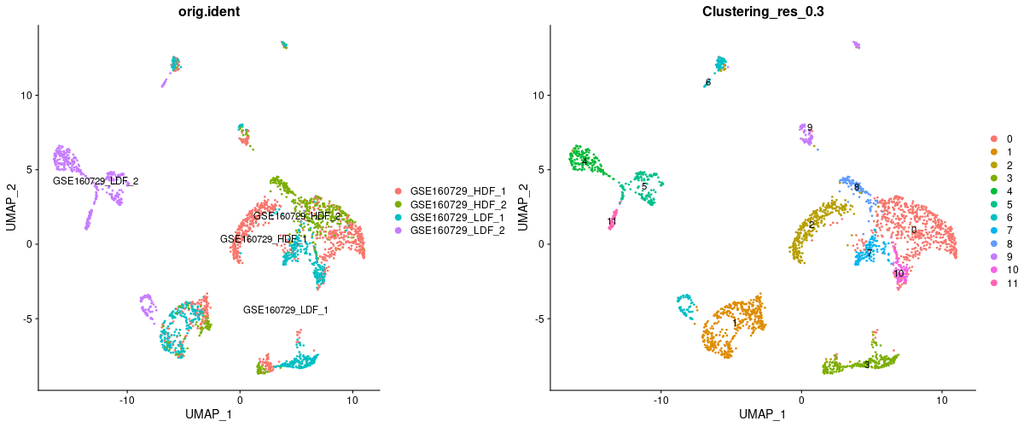

Notice cells are not only grouped by their sample of origin, but in addition to that, sample LFD2 gets almost complitely isolated even from the other low fat diet sample.

Getting back to our results, in the “Dataset Plots” tab we can check how the cells on each sample distribute in the different clusters:

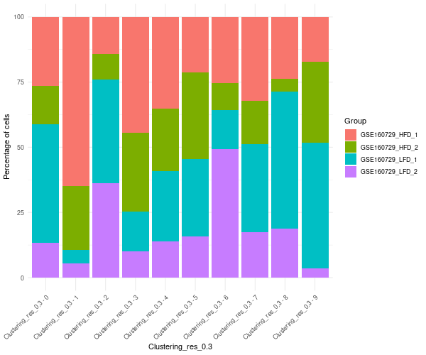

At first glance we can distinguish several clusters whose composition is strongly biased towards one of the conditions, like cluster 1 and high fat diet, and cluster 2 and low fat diet.

### Identify the cell types

Now we’ll text differential gene expression. Following the steps in Case Example 1, in the *Differential Expression* tab select “Clustering_res_0.3” as the grouping variable and “1 VS rest” as the testing mode. We’ll lower the minimum ±Log<sub>2</sub>(Fold Change ) to 0.2 in order to have more genes included in the resulting tables. Here’s a summary of the differential expression results:

| Comparison | Cells in Foreground | Cells in Background | Total DEG | Up regulated Genes | Down regulated Genes |
| --- | --- | --- | --- | --- | --- |
| 0 VS rest | 492 | 2064 | 465 | 331 | 134 |
| 1 VS rest | 448 | 2108 | 753 | 196 | 557 |
| 2 VS rest | 430 | 2126 | 1521 | 1289 | 232 |
| 3 VS rest | 355 | 2201 | 460 | 363 | 97 |
| 4 VS rest | 343 | 2213 | 277 | 165 | 112 |
| 5 VS rest | 132 | 2424 | 1185 | 1139 | 46 |
| 6 VS rest | 126 | 2430 | 202 | 122 | 80 |
| 7 VS rest | 121 | 2435 | 77 | 18 | 59 |
| 8 VS rest | 80 | 2476 | 165 | 157 | 8 |
| 9 VS rest | 29 | 2527 | 347 | 344 | 3 |

This study uses ENSEMBL IDs as gene identifiers, so we’ll have to use the same format for the markers:

| Cell type | Markers (MGI symbol) | Markers (ENSEMBL gene ID ) |
| --- | --- | --- |
| FAP | Col1a1, Dcn, Pdgfra | ENSMUSG00000001506, ENSMUSG00000019929, ENSMUSG00000029231 |
| Adipocyte | Lipe, Plin1, Pparg | ENSMUSG00000003123, ENSMUSG00000030546, ENSMUSG00000000440 |
| Mesothelium | Upk3b, Gpm6a, Msln | ENSMUSG00000042985, ENSMUSG00000031517, ENSMUSG00000063011 |
| Epididymis | Ces5a, Abcb5, Adam7 | ENSMUSG00000058019, ENSMUSG00000072791, ENSMUSG00000022056 |
| Spermatozoa | Spef2, Hydin, Dnah12 | ENSMUSG00000072663, ENSMUSG00000059854, ENSMUSG00000021879 |
| Endotheluim | Esam, Flt1, Vwf | ENSMUSG00000001946, ENSMUSG00000029648, ENSMUSG00000001930 |
| Immune cell | Adgre1, Lyz2, Ccl6 | ENSMUSG00000004730, ENSMUSG00000069516, ENSMUSG00000018927 |

This cell type marker list was taken from [Figure 1G](https://doi.org/10.1016/j.cmet.2020.12.004) of the paper describing the study we are using. With this marker list we can identify almost all clusters:

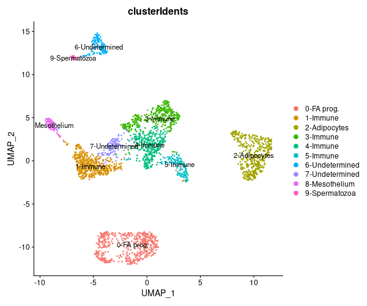

Cluster 6 and 7 are the only ones we cant identify at the first try:

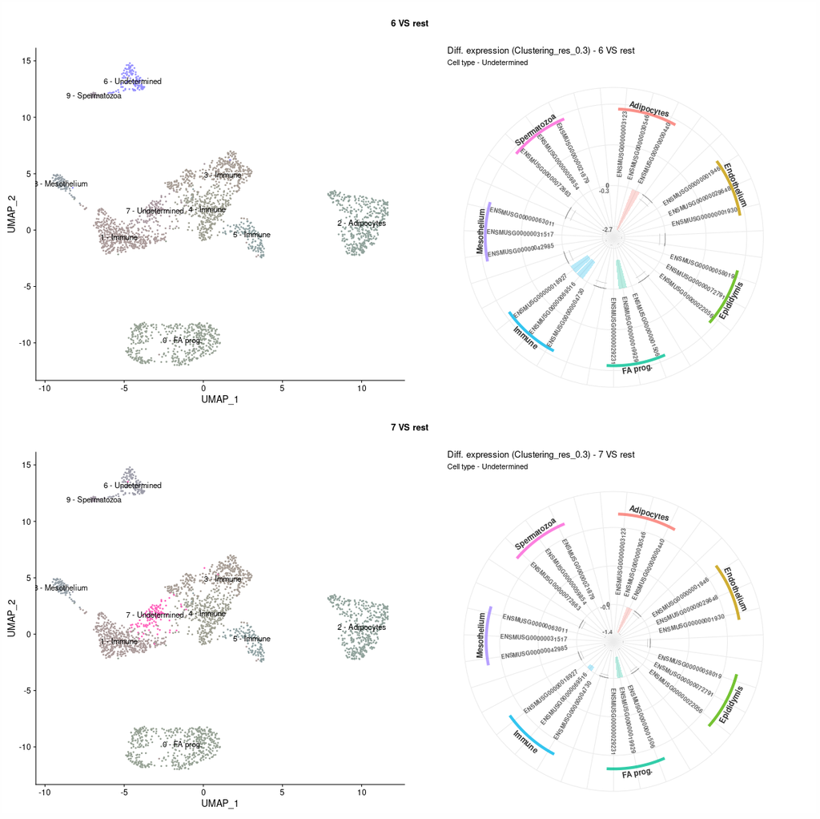

If we go back to the differential expression tab or open the exported excel file and look at the top differentially expressed genes of this two clusters:

- For cluster 7, the top three genes (ENSMUSG00000032035, ENSMUSG00000049744, and ENSMUSG00000057058, or Ets1, Arhgap15, and Skap1) correlate with T-cell identity.
- For cluster 6, on the other hand, the top DE genes tend to be expressed only in a portion of the cells of the cluster, suggesting that this could be a mix of different but similar cell types.

From this point onward there are several strategies we could follow to gather more information:

- Find cell-type specific changes mediated by a high-fat diet: in clusters which composition is more balanced, we can use the Conditional mode to calculate differential expression due to the diet in each cluster intependently.
- Define the cell clusters strongly tied to the treatment, like immune cells in cluster 1, which are predominantly coming from mice fed a high-fat diet. To gather what makes these obese-type immune cells different from the rest we could calculate differential expression in a “1 VS 1” mode comparing cluster 1 to the rest of immune cell clusters (C3, C4, C5, and C7).

Both of this approaches, since they’re more focused in smaller-level detail of gene expression, will also be frequently linked to specific molecular pathways or biological functions. The *Altered Pathways* tab offers a tool to find molecular pathways enriched in differentially expressed genes.